# Hoja 2 de problemas y prácticas con R

Estadística Computacional I. Grado en Estadística

Departamento de Estadística e Investigación Operativa. Universidad de Sevilla

# Generar una muestra

De las calificaciones de 50 alumnos con el comando:

```
`sample(c("1S","2A","3N","4SB","5MH"),prob=c(0.3,0.35,0.2,0.1,0.05),50,rep=T)`.
```

```r
set.seed(12345)
m1=sample(c("1S","2A","3N","4SB","5MH"),
          prob=c(0.3,0.35,0.2,0.1,0.05),50,rep=T)
m1
```

```
##  [1] "3N"  "4SB" "3N"  "4SB" "1S"  "2A"  "2A"  "1S"  "3N"  "5MH" "2A"  "2A"
## [13] "3N"  "2A"  "1S"  "1S"  "1S"  "1S"  "2A"  "5MH" "1S"  "2A"  "5MH" "3N"
## [25] "1S"  "1S"  "3N"  "1S"  "2A"  "1S"  "3N"  "2A"  "2A"  "3N"  "1S"  "1S"
## [37] "4SB" "4SB" "1S"  "2A"  "3N"  "1S"  "4SB" "3N"  "2A"  "2A"  "2A"  "2A"
## [49] "2A"  "1S"
```

## Resumir valores

Mediante una tabla de frecuencias incluyendo frecuencias absolutas, frecuencias relativas, porcentajes, y los acumulados de las tres características.

```r
tablafre=tibble(valores=m1) %>%
  group_by(valores) %>%
  summarise(
    ni=n() # Frecuencias absolutas
    ) %>%
  mutate(
    fi=ni /length(m1), #Frec rel
    pi=fi*100, #Porcentajes
    Ni=cumsum(ni),
    Fi=cumsum(fi),#Ni/length(m1)
    Pi=cumsum(pi)
    )

tablafre %>%
  kable(booktabs=TRUE) %>%
  kable_styling(latex_options = "striped"  )
```

| valores | ni | fi | pi | Ni | Fi | Pi |
| --- | --- | --- | --- | --- | --- | --- |
| 1S | 16 | 0.32 | 32 | 16 | 0.32 | 32 |
| 2A | 16 | 0.32 | 32 | 32 | 0.64 | 64 |
| 3N | 10 | 0.20 | 20 | 42 | 0.84 | 84 |
| 4SB | 5 | 0.10 | 10 | 47 | 0.94 | 94 |
| 5MH | 3 | 0.06 | 6 | 50 | 1.00 | 100 |

## Obtener representaciones gráficas adecuadas de las medidas anteriores.

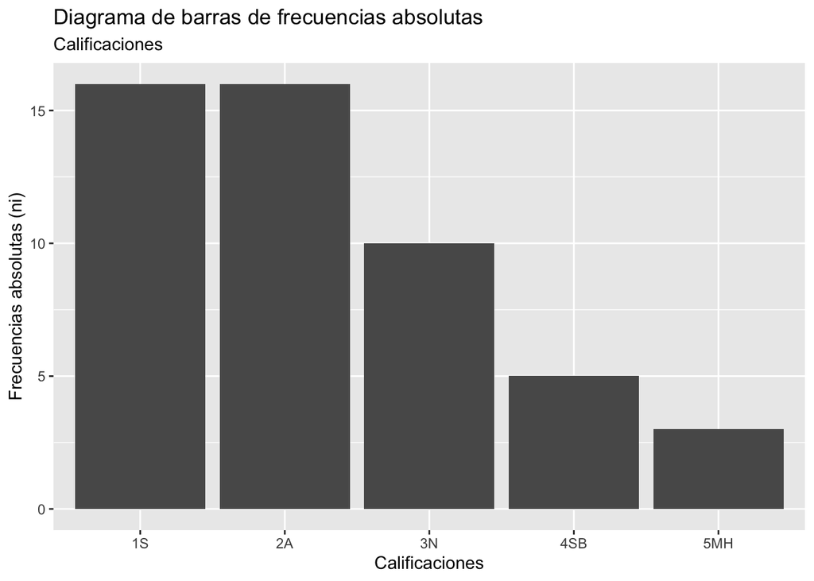

```r
tablafre %>%
  ggplot(aes(x=valores , y = ni)) +
  geom_col()+
  labs(
    title = "Diagrama de barras de frecuencias absolutas",
    subtitle = "Calificaciones",
    y="Frecuencias absolutas (ni)",
    x="Calificaciones"
  )
```

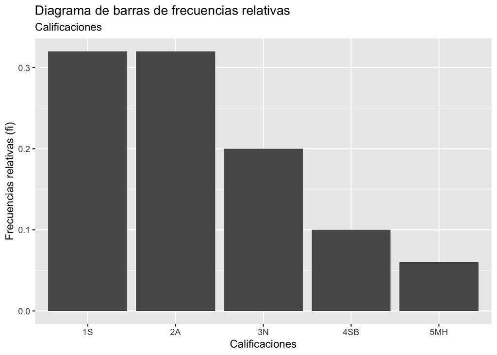

```r
tablafre %>%
  ggplot(aes(x=valores , y = fi)) +
  geom_col()+
  labs(
    title = "Diagrama de barras de frecuencias relativas",
    subtitle = "Calificaciones",
    y="Frecuencias relativas (fi)",
    x="Calificaciones"
  )
```

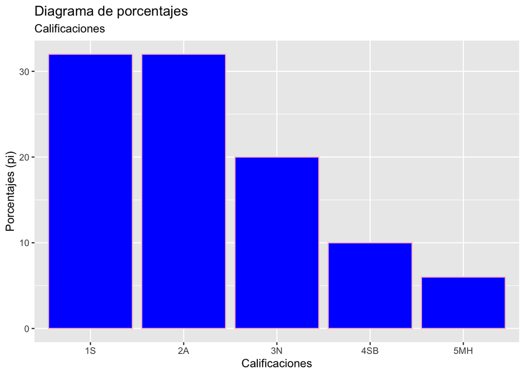

```r
tablafre %>%
  ggplot(aes(x=valores , y = pi)) +
  geom_col( color = "pink", fill ="blue")+
  labs(
    title = "Diagrama de porcentajes",
    subtitle = "Calificaciones",
    y="Porcentajes (pi)",
    x="Calificaciones"
  )
```

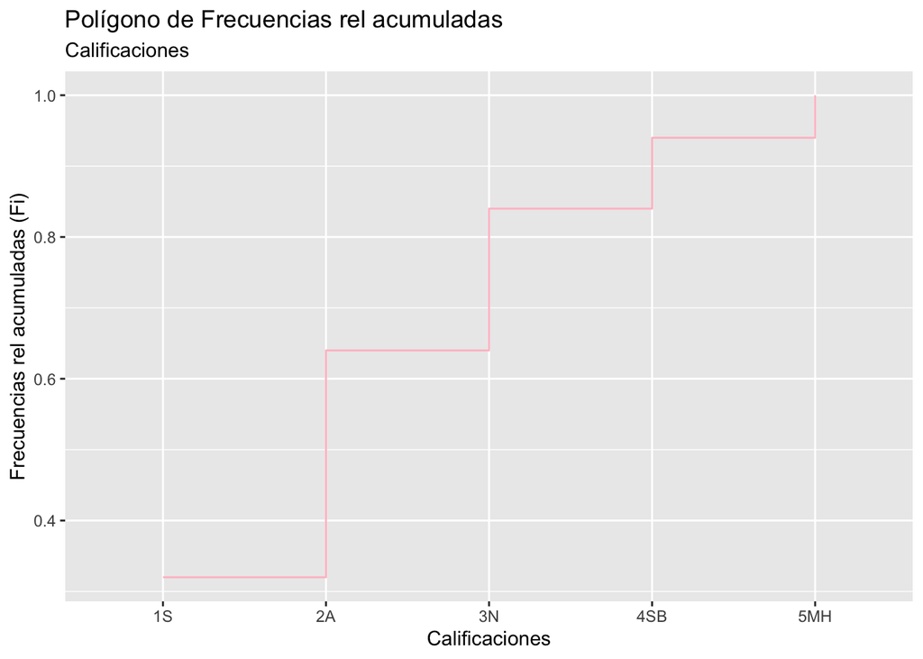

```r
tablafre %>%
  ggplot(aes(x=valores , y = Fi, group=1)) +
 # geom_col(color="blue") +
 # geom_line(color="pink")+ # Si no pongo group=1 no me hace la representación gráfica. Es para variables continuas
  geom_step(col="pink")+ #Variables discretas
  labs(
    title = "Polígono de Frecuencias rel acumuladas",
    subtitle = "Calificaciones",
    y="Frecuencias rel acumuladas (Fi)",
    x="Calificaciones"
  )
```

Diagrama de sectores con el sistema base:

```r
tablafre$fi
```

```
## [1] 0.32 0.32 0.20 0.10 0.06
```

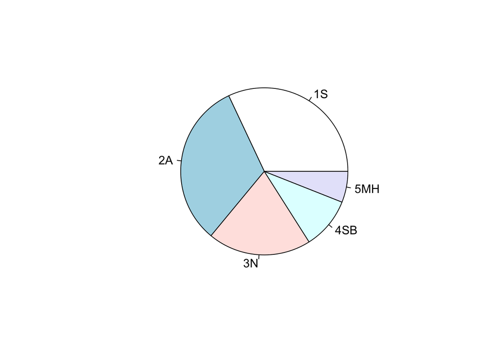

```r
pie(tablafre$ni, labels = tablafre$valores)
```

Diagrama de sectores con ggplot2:

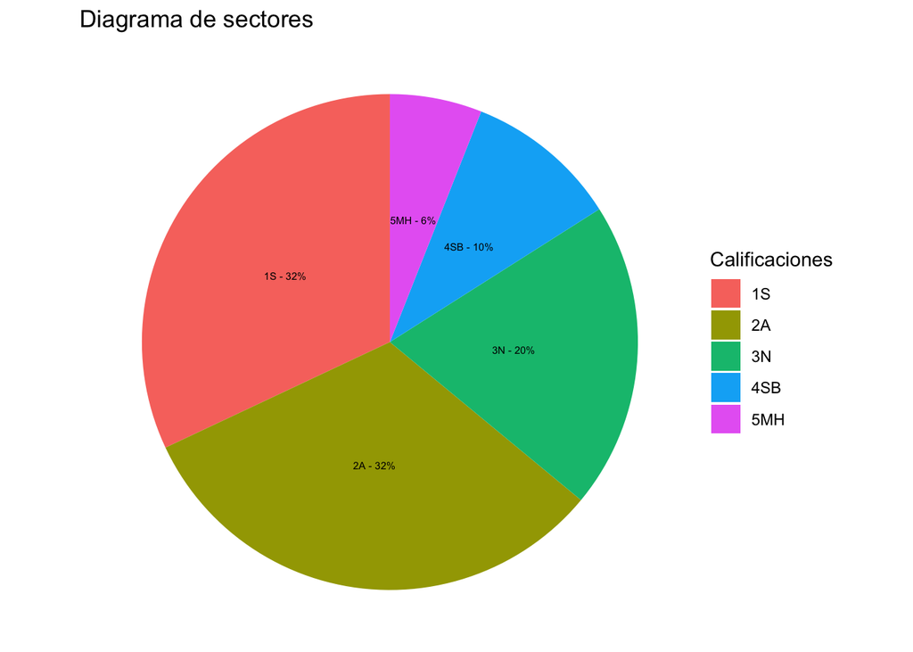

```r
tablafre %>%
  ggplot(aes(x="",y=pi, fill=factor(valores)))+
  geom_bar(width = 1, stat = "identity")+
  coord_polar("y",start = 0)+
  theme_void() +
  geom_text(aes(label=paste0(valores," - ",         round(pi,2), "%")),
   position=position_stack(vjust=0.5), size=2 ) +
  labs(
    title = "Diagrama de sectores",
    fill= "Calificaciones"
  )
```

# Fichero “Familia.txt”

El fichero “Familia.txt” contiene el peso (kgs) y la altura (cms) de los integrantes de una familia.

## Leer en R este fichero y calcular la media y la cuasidesviación típica de cada variable.

```r
datos2=read.table(file="Familia.txt",sep=" ")
head(datos2) %>%
  kable(booktabs=TRUE) %>%
kable_styling(latex_options = "striped")
```

|  | Altura | Peso |
| --- | --- | --- |
| Sobrina | 120 | 22 |
| Hijo | 172 | 52 |
| Abuelo | 163 | 71 |
| Hija | 158 | 51 |
| Sobrino | 153 | 51 |
| Abuela | 148 | 60 |

```r
datos2 %>%
  summarise(
    MediaAltura=mean(Altura),
    MediaPeso = mean(Peso),
    SdAltura=sd(Altura),
    SdPeso=sd(Peso)
  ) %>%
  kable(booktabs=TRUE) %>%
kable_styling(latex_options = "striped")
```

| MediaAltura | MediaPeso | SdAltura | SdPeso |
| --- | --- | --- | --- |
| 156.6 | 54.1 | 14.93839 | 13.56835 |

Otra forma:

```r
datos2 %>%
  summarise_each(
   c( sd, mean)) %>%
  kable(booktabs=TRUE) %>%
kable_styling(latex_options = "striped")
```

| Altura_fn1 | Peso_fn1 | Altura_fn2 | Peso_fn2 |
| --- | --- | --- | --- |
| 14.93839 | 13.56835 | 156.6 | 54.1 |

Otra forma:

```r
datos2 %>%
  summarise_all(
    list(mean,sd)
  )  %>%
kable(booktabs=TRUE) %>%
  kable_styling(latex_options = "striped")
```

| Altura_fn1 | Peso_fn1 | Altura_fn2 | Peso_fn2 |
| --- | --- | --- | --- |
| 156.6 | 54.1 | 14.93839 | 13.56835 |

## Nube de puntos y recta de mínimos cuadrados

Dibujar la nube de puntos (Peso, Altura) y superponer la recta de mínimos cuadrados. Calcular el coeficiente de correlación lineal entre ambas variables.

Coeficiente de correlación lineal

```r
datos2 %>%
  summarise(
    Ccirlineal=cor(Peso,Altura)
    )-> ccl
```

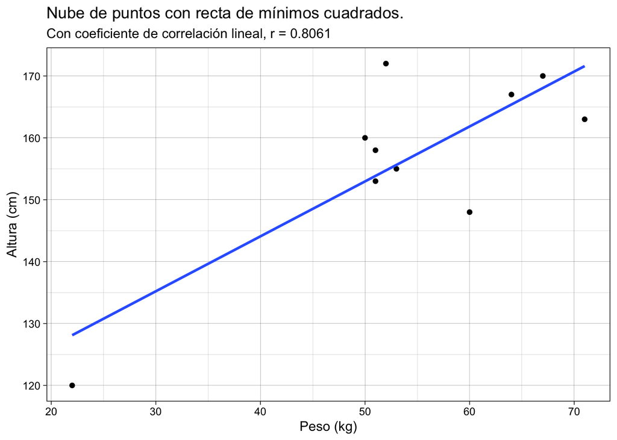

```r
ggplot(data=datos2, aes(Peso,Altura)) +
  geom_point()+
  geom_smooth(method=lm, se=FALSE, formula = y~x)+  #Quito los IC
  labs(
    title = "Nube de puntos con recta de mínimos cuadrados.",
    subtitle = paste0("Con coeficiente de correlación lineal, r = " , round(ccl,4)),
    y="Altura (cm)",
    x="Peso (kg)" )+
  theme_linedraw()
```

## Outliers

¿Qué observación es outlier para la variable peso? Repetir el apartado anterior sin esa persona.

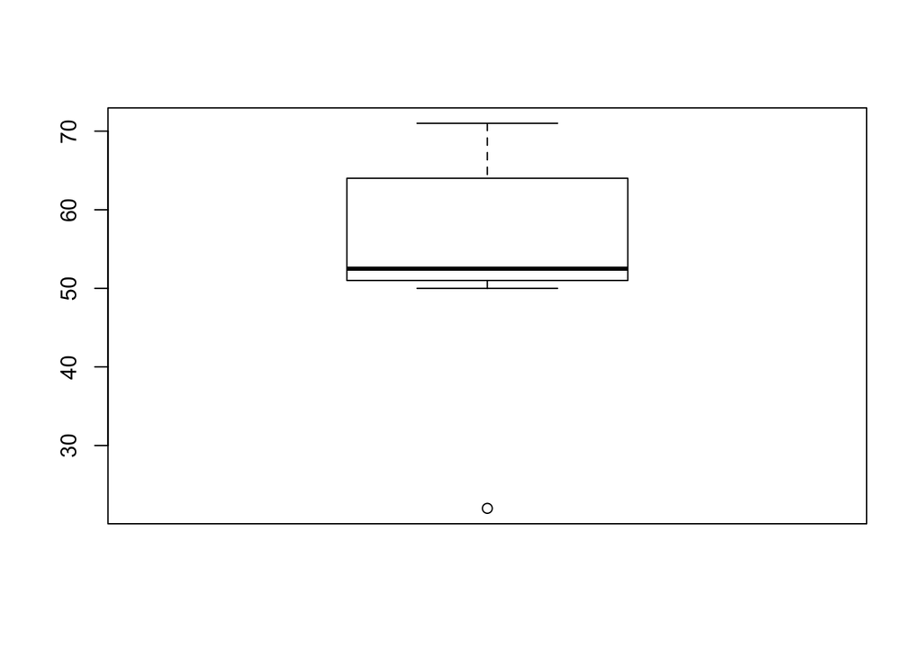

```r
res2=boxplot(datos2$Peso)
```

```r
res2 # Mirlo las estadísticas del diagrama.
```

```
## $stats
##      [,1]
## [1,] 50.0
## [2,] 51.0
## [3,] 52.5
## [4,] 64.0
## [5,] 71.0
## attr(,"class")
##         1
## "integer"
##
## $n
## [1] 10
##
## $conf
##          [,1]
## [1,] 46.00468
## [2,] 58.99532
##
## $out
## [1] 22
##
## $group
## [1] 1
##
## $names
## [1] "1"
```

```r
datos2 %>%
  arrange(Peso) %>%
  head(1)
```

```
##         Altura Peso
## Sobrina    120   22
```

```r
datos2new=datos2[-1,]
```

```r
datos2new %>%
  summarise(
    Ccirlineal=cor(Peso,Altura)
    )-> ccl
```

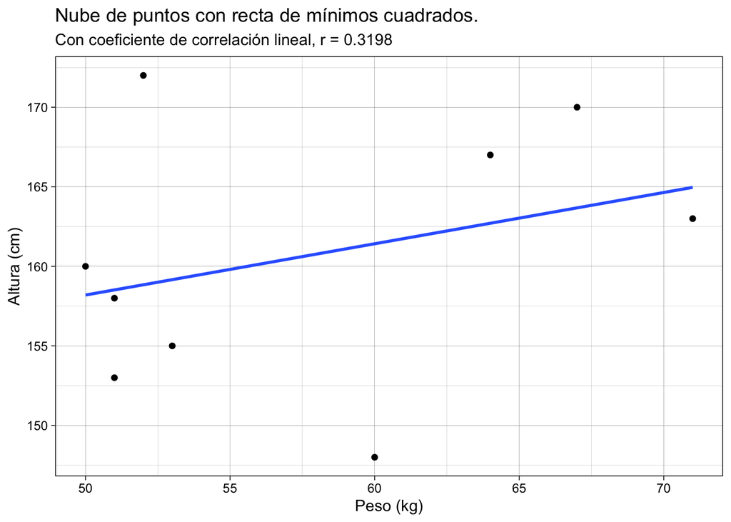

```r
ggplot(data=datos2new, aes(Peso,Altura)) +
  geom_point()+
  geom_smooth(method=lm, se=FALSE, formula = y~x)+  #Quito los IC
  labs(
    title = "Nube de puntos con recta de mínimos cuadrados.",
    subtitle = paste0("Con coeficiente de correlación lineal, r = " , round(ccl,4)),
    y="Altura (cm)",
    x="Peso (kg)" )+
  theme_linedraw()
```

## IMC

Calcular el Índice de Masa Corporal (IMC), definido como el cociente entre el peso y el cuadrado de la altura (en metros). Representarlo con un gráfico de barras.

```r
dat2imc= datos2 %>%
  mutate(IMC=Peso/((Altura/100)^2))

dat2imc %>%
  kable(booktabs=TRUE) %>%
kable_styling(latex_options = "striped")
```

|  | Altura | Peso | IMC |
| --- | --- | --- | --- |
| Sobrina | 120 | 22 | 15.27778 |
| Hijo | 172 | 52 | 17.57707 |
| Abuelo | 163 | 71 | 26.72287 |
| Hija | 158 | 51 | 20.42942 |
| Sobrino | 153 | 51 | 21.78649 |
| Abuela | 148 | 60 | 27.39226 |
| Tía | 160 | 50 | 19.53125 |
| Tío | 170 | 67 | 23.18339 |
| Madre | 155 | 53 | 22.06035 |
| Padre | 167 | 64 | 22.94812 |

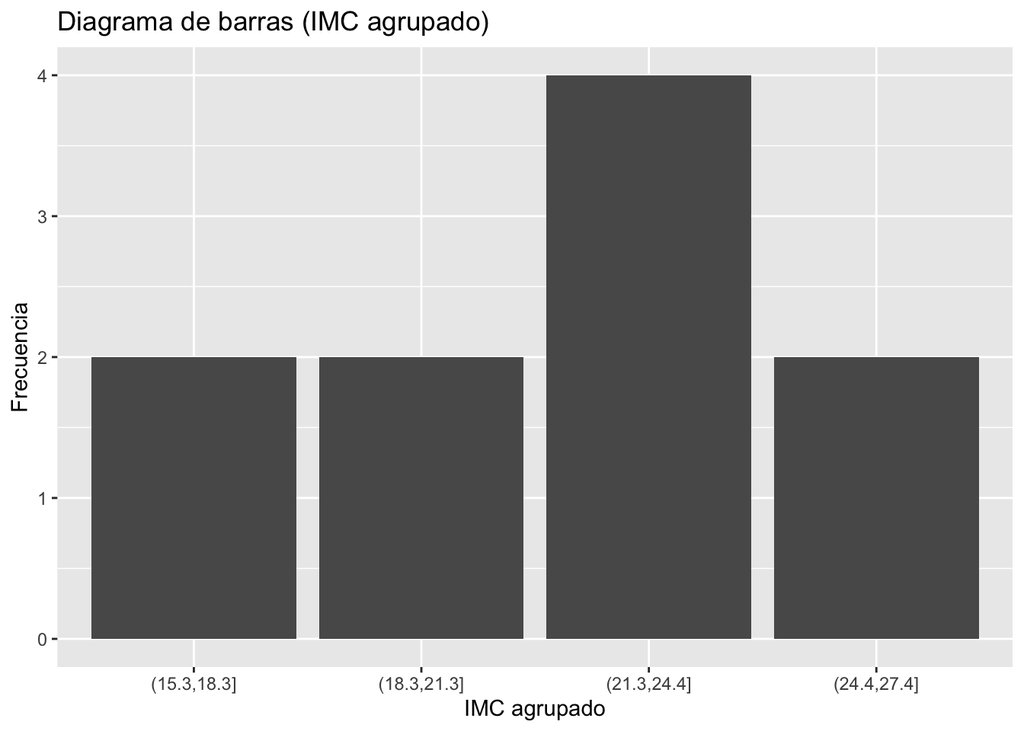

```r
dat2imc %>%
  mutate(
    IMCargu=cut(IMC,breaks=4)
  ) %>% ggplot(aes(x=IMCargu))+
  geom_bar()+
  labs(

  x="IMC agrupado",
  y="Frecuencia",
  title="Diagrama de barras (IMC agrupado)"
  )
```

## Ordenar

Ordenar los familiares de mayor a menor IMC.

```r
dat2imc %>%
  arrange(desc(IMC  ) ) %>%
  kable(booktabs=TRUE) %>%
  kable_styling(latex_options = "striped")
```

|  | Altura | Peso | IMC |
| --- | --- | --- | --- |
| Abuela | 148 | 60 | 27.39226 |
| Abuelo | 163 | 71 | 26.72287 |
| Tío | 170 | 67 | 23.18339 |
| Padre | 167 | 64 | 22.94812 |
| Madre | 155 | 53 | 22.06035 |
| Sobrino | 153 | 51 | 21.78649 |
| Hija | 158 | 51 | 20.42942 |
| Tía | 160 | 50 | 19.53125 |
| Hijo | 172 | 52 | 17.57707 |
| Sobrina | 120 | 22 | 15.27778 |

# Librería *ISwR*

Acceder al fichero alkfos de la librería ISwR:

```r
library(ISwR)
data(alkfos) # Cargamos los datos
alkfos %>%
  kable(booktabs=TRUE,longtable=T,caption="Fichero alkfos") %>%
  kable_styling(latex_options = c("striped","repeat_header"))
```

Fichero alkfos

| grp | c0 | c3 | c6 | c9 | c12 | c18 | c24 |
| --- | --- | --- | --- | --- | --- | --- | --- |
| 1 | 142 | 140 | 159 | 162 | 152 | 175 | 148 |
| 1 | 120 | 126 | 120 | 146 | 134 | 119 | 116 |
| 1 | 175 | 161 | 168 | 164 | 213 | 194 | 221 |
| 1 | 234 | 203 | 174 | 197 | 289 | 174 | 189 |
| 1 | 94 | 107 | 146 | 124 | 128 | 98 | 114 |
| 1 | 128 | 97 | 113 | 203 | NA | NA | NA |
| 1 | 202 | 189 | 208 | 203 | 209 | 200 | 218 |
| 1 | 190 | 277 | 270 | 171 | 141 | 192 | 190 |
| 1 | 104 | 117 | 135 | 122 | 112 | 133 | 123 |
| 1 | 112 | 95 | 114 | 122 | 118 | 119 | 138 |
| 1 | 160 | 169 | 178 | 208 | 220 | 215 | 232 |
| 1 | 214 | 211 | 215 | 240 | 227 | 288 | 260 |
| 1 | 113 | 138 | 112 | 114 | 109 | 106 | 111 |
| 1 | 237 | 245 | 219 | 213 | 215 | 225 | 228 |
| 1 | 205 | 213 | 248 | 222 | 225 | 207 | 172 |
| 1 | 202 | 231 | 236 | 185 | 204 | 226 | 147 |
| 1 | 137 | 128 | 136 | 146 | 152 | 132 | 150 |
| 1 | 175 | 163 | 167 | 144 | 168 | NA | NA |
| 1 | 174 | 151 | 150 | 133 | 134 | 149 | 146 |
| 1 | 81 | 81 | 83 | 74 | 82 | 84 | 108 |
| 1 | 113 | 131 | 298 | 124 | 126 | 140 | 129 |
| 1 | 104 | 114 | 124 | 102 | 94 | 122 | 125 |
| 1 | 178 | 172 | 159 | 155 | 157 | 153 | 164 |
| 2 | 150 | 122 | 103 | 109 | 103 | 87 | 109 |
| 2 | 173 | 127 | 117 | 124 | 143 | 123 | 144 |
| 2 | 191 | 174 | 165 | 160 | 177 | 184 | NA |
| 2 | 191 | 159 | 157 | 161 | 150 | 187 | 215 |
| 2 | 230 | 150 | 144 | 153 | 125 | 124 | 152 |
| 2 | 145 | 134 | 167 | 141 | 112 | 212 | 194 |
| 2 | 128 | 92 | 89 | 78 | 83 | 78 | 80 |
| 2 | 102 | 86 | 80 | 76 | 82 | 79 | 68 |
| 2 | 180 | 124 | 116 | 117 | 124 | NA | NA |
| 2 | 153 | 96 | 97 | 96 | 93 | 156 | 110 |
| 2 | 115 | 79 | 79 | 79 | 73 | 69 | 72 |
| 2 | 150 | 113 | 124 | 102 | 100 | 109 | 101 |
| 2 | 182 | 147 | 156 | 79 | 135 | NA | 162 |
| 2 | 175 | 146 | 157 | 140 | 143 | 158 | 162 |
| 2 | 146 | 86 | 81 | 80 | 87 | 89 | 95 |
| 2 | 92 | 80 | 95 | 95 | 86 | 119 | NA |
| 2 | 228 | 177 | 185 | 181 | 190 | 182 | 192 |
| 2 | 178 | 119 | 107 | NA | 102 | 110 | 94 |
| 2 | 213 | 185 | 152 | 142 | 158 | 178 | 194 |
| 2 | 161 | 107 | 104 | 107 | NA | 118 | 129 |

## Ver los primeros casos y los últimos.

```r
alkfos[c(1,2,3,41,42,43),] %>%
  kable(booktabs=TRUE) %>%
  kable_styling(latex_options = "striped", stripe_index = c(1,2,5:6))
```

|  | grp | c0 | c3 | c6 | c9 | c12 | c18 | c24 |
| --- | --- | --- | --- | --- | --- | --- | --- | --- |
| 1 | 1 | 142 | 140 | 159 | 162 | 152 | 175 | 148 |
| 2 | 1 | 120 | 126 | 120 | 146 | 134 | 119 | 116 |
| 3 | 1 | 175 | 161 | 168 | 164 | 213 | 194 | 221 |
| 41 | 2 | 178 | 119 | 107 | NA | 102 | 110 | 94 |
| 42 | 2 | 213 | 185 | 152 | 142 | 158 | 178 | 194 |
| 43 | 2 | 161 | 107 | 104 | 107 | NA | 118 | 129 |

```r
alkfos %>% head() %>%  tail()
```

```
##   grp  c0  c3  c6  c9 c12 c18 c24
## 1   1 142 140 159 162 152 175 148
## 2   1 120 126 120 146 134 119 116
## 3   1 175 161 168 164 213 194 221
## 4   1 234 203 174 197 289 174 189
## 5   1  94 107 146 124 128  98 114
## 6   1 128  97 113 203  NA  NA  NA
```

## Reformatear los datos a la estructura grp time c id.

Grupo, tiempo y valor observado.

```r
alkfos_fl = alkfos %>%
  pivot_longer(names_to = "cid",
               values_to = "time",
               cols = -grp) %>%
  #para que aparezca primero el 3 luego el 6... sería conveniente quitar la c
  mutate(
    cid=as.integer(gsub("c","",cid))
  ) %>%
  select(grp,time,cid)
View(alkfos_fl)
```

## Ordenar el nuevo formato por grp, id y time, y mostrar las variables en el orden (grp, id, time, c).

```r
alkfos_fl %>%
  arrange(grp,cid,time) %>%
  select(grp,cid,time) %>%
  head(6) %>%
  tail(6) %>%
  kable(booktabs=TRUE) %>%
  kable_styling("striped")
```

| grp | cid | time |
| --- | --- | --- |
| 1 | 0 | 81 |
| 1 | 0 | 94 |
| 1 | 0 | 104 |
| 1 | 0 | 104 |
| 1 | 0 | 112 |
| 1 | 0 | 113 |

[figure not shown]

# Fichero *“dietas.dat”*

```r
dietas=read.table("dietas.dat",sep = " ",col.names = paste0("Dieta_",c(1:7)))
```

Cada variable toma valores de 1 a 6, a mayor valor más lejos del peso ideal. Representar gráficamente la evolución de los pesos medios según la dieta.

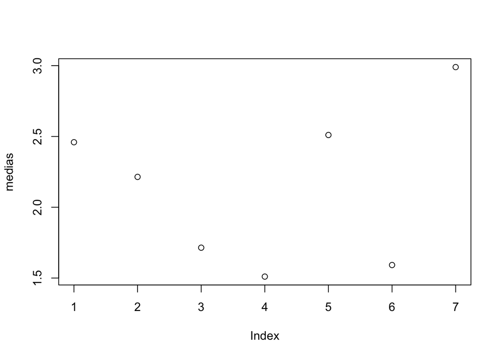

```r
medias=c(
mean(dietas[,1]),
mean(dietas[,2]),
mean(dietas[,3]),
mean(dietas[,4]),
mean(dietas[,5]),
mean(dietas[,6]),
mean(dietas[,7]))

plot(medias)
```

*En este problema se trabajará con el conjunto de datos Boston de la librería MASS.*

## Acceder a los datos, en particular, averiguar qué información contiene y cuál es la dimensionalidad de los datos.

## Ordenar las variables según el valor absoluto de su coeficiente de correlación lineal con medv (variable a predecir en este conjunto de datos).

## ¿Destaca algún distrito por su tasa de criminalidad? Similarmente, por los impuestos sobre la propiedad o por la ratio alumnos-profesor.

## ¿Cuántos distritos son limítrofes con el río? Calcular las medias de crim y medv según chas.

## Analizar la relación lineal entre lstat y medv.

# Comprobar empíricamente el Teorema de Fisher a partir de 5000 muestras de tamaño 10 de una ley N(0,1):

## Analizar la relación lineal entre las medias y las cuasivarianzas.

## Estudiar gráficamente si los cocientes (n-1)*cuasivar/(sigma^2) siguen una ley chi-cuadrado.

# Comprobar mediante una simulación el ajuste de las distribuciones chi-cuadrado y la distribución F-Snedecor a partir de las cuasivarianzas muestrales para 10000 pares de muestras independientes. En cada par, la primera muestra será de tamaño 10 de la ley N(0,1), y la segunda muestra de tamaño 8 de la ley N(10,3).

# Fichero *“salarios.txt”*

El fichero “salarios.txt” contiene datos sobre el salario (variable wage) y otras características para 3000 trabajadores.

## Representar gráficamente los salarios según las variables age, year y education, y superponer estimaciones de la media del salario según cada variable.

## Dibujar la evolución anual del salario medio según el nivel educativo.

## Calcular los porcentajes de variación interanual del salario medio según nivel educativo.

## Ordenar el fichero de datos según año (creciente) y edad (decreciente).

# Librería *MASS*

Acceder al data frame painters de la librería MASS.

## Interpretar y resumir la información contenida en este fichero de datos.

## Seleccionar las escuelas del renacimiento y Veneciana para los siguientes apartados.

## Generar en una sola pantalla los diagramas de caja y bigotes según la escuela.

## Construir nubes de puntos en las que se distinga la escuela.

## Comparar mediante gráficos de barras las medias de ambas escuelas.